# An Algebraic View of Multiple Regression

Author

Rick Dean

Abstract

The following are R scripts/notes on the article [An Algebraic View of Multiple Regression](https://dasilvaa10.github.io/b1/) by [Alex daSilva](https://dasilvaa10.github.io/).

Load the Required R Packages:

```r
library(data.table)
library(ggplot2)
library(purrr)
library(gt)
library(magrittr)
library(RplotterPkg)
library(RregressPkg)
```

## Time to dive in!

Start with the data package “mtcars” and its three variables *mpg*, *hp*, and *disp*.

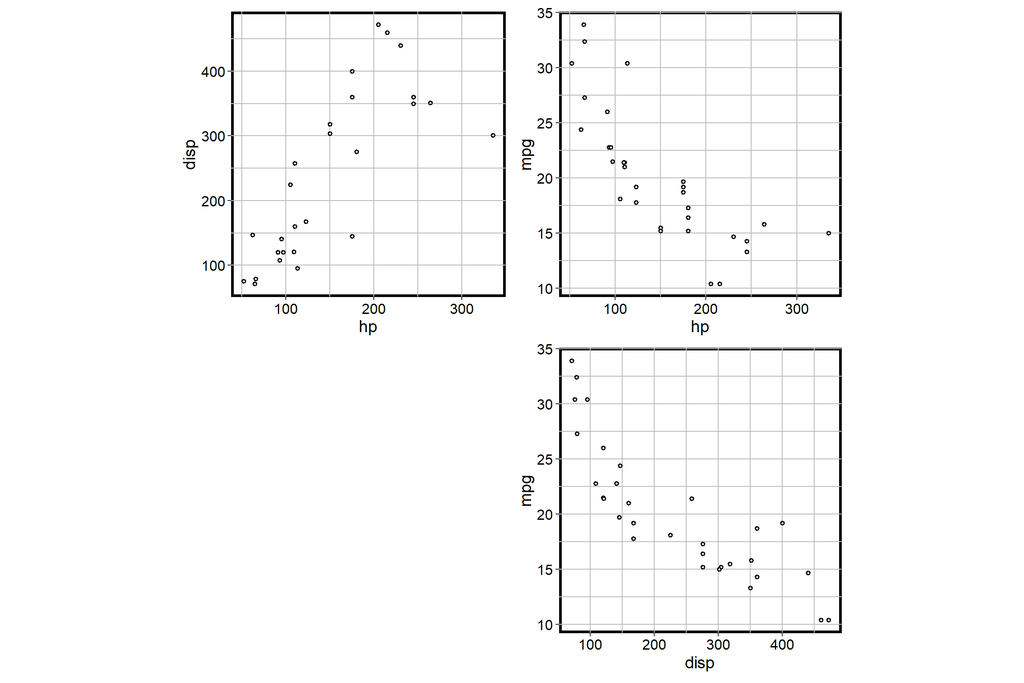

Scatterplots of mtcars variable pairs

```r
mtcars_dt <- data.table::as.data.table(mtcars) %>%
  .[, .(hp, disp, mpg)]

RregressPkg::plot_pairs(
  df = mtcars_dt,
  var_name_scaling = list(
    hp = NULL,
    disp = NULL,
    mpg = NULL
  ),
  axis_text_sz = 12,
  rot_y_tic_label = T,
  plot_dim = 20
)
```

Show the summary of the linear model *mpg ~ hp + disp*.

```r
mpg_formula_obj <- lm(mpg ~ hp + disp, data = mtcars)
summary(mpg_formula_obj)
```

```
Call:
lm(formula = mpg ~ hp + disp, data = mtcars)

Residuals:
    Min      1Q  Median      3Q     Max
-4.7945 -2.3036 -0.8246  1.8582  6.9363

Coefficients:
             Estimate Std. Error t value Pr(>|t|)
(Intercept) 30.735904   1.331566  23.083  < 2e-16 ***
hp          -0.024840   0.013385  -1.856 0.073679 .
disp        -0.030346   0.007405  -4.098 0.000306 ***
---
Signif. codes:  0 '***' 0.001 '**' 0.01 '*' 0.05 '.' 0.1 ' ' 1

Residual standard error: 3.127 on 29 degrees of freedom
Multiple R-squared:  0.7482,    Adjusted R-squared:  0.7309
F-statistic: 43.09 on 2 and 29 DF,  p-value: 2.062e-09
```

Our goal is to recreate the *lm* model.

Partition off our response and predictor variables into separate matrices.

```r
y_mt <- as.matrix(mtcars[, "mpg"])
x_mt <- data.table(
  x0 = rep(1,nrow(mtcars_dt)),
  hp = mtcars_dt$hp,
  disp = mtcars_dt$disp
) %>%
  as.matrix(.)
head(x_mt)
```

```
     x0  hp disp
[1,]  1 110  160
[2,]  1 110  160
[3,]  1  93  108
[4,]  1 110  258
[5,]  1 175  360
[6,]  1 105  225
```

The above *x_mt* matrix is sometimes referred to as the **design matrix** which currently consist of two predictor variables and an intercept variable.

## Now, the fun begins

Finding our beta coefficients.

In order to do this, we need to find $(X^{T}X)^{-1}$ and multiple by $X^{T}Y$

```r
XtX_mt <- t(x_mt) %*% x_mt
XtY_mt <- t(x_mt) %*% y_mt
```

*XtX_mt* has the sum of the squared values along the diagonal, and cross-products on the off diagonal of the predictors.

*XtY_mt* has the cross-products of the predictors with the response variable.

Back to betas

As mentioned above $b = (X^{T}X)^{-1}X^{T}Y$.

```r
betas_mt <- solve(XtX_mt) %*% XtY_mt
```

## Put a hat on it

Compute the hat matrix or projection matrix.

The hat matrix allows us to map $y$ into $\hat{y}$. The hat matrix formula:
$$H = X(X^{T}X)^{-1}X^{T}$$
> Once we have calculated the hat matrix, we multiply it by $y$ to find our predicted values.

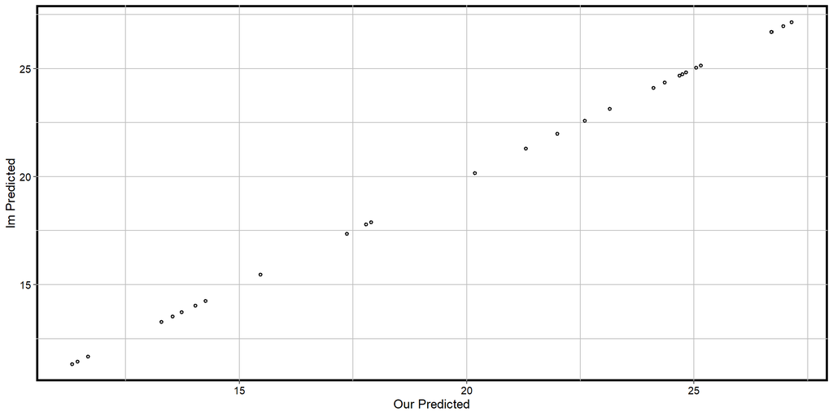

Our predicted vs lm predicted

```r
h_mt = x_mt %*% solve(XtX_mt) %*% t(x_mt)
predicted_mt <- h_mt %*% y_mt

dt <- data.table(
  x = predicted_mt[,1],
  y = mpg_formula_obj$fitted.values
)

RplotterPkg::create_scatter_plot(
  df = dt,
  aes_x = "x",
  aes_y = "y",
  x_title = "Our Predicted",
  y_title = "lm Predicted",
  rot_y_tic_label = T
)
```

Compute the residuals and compare with residuals from the *lm*.

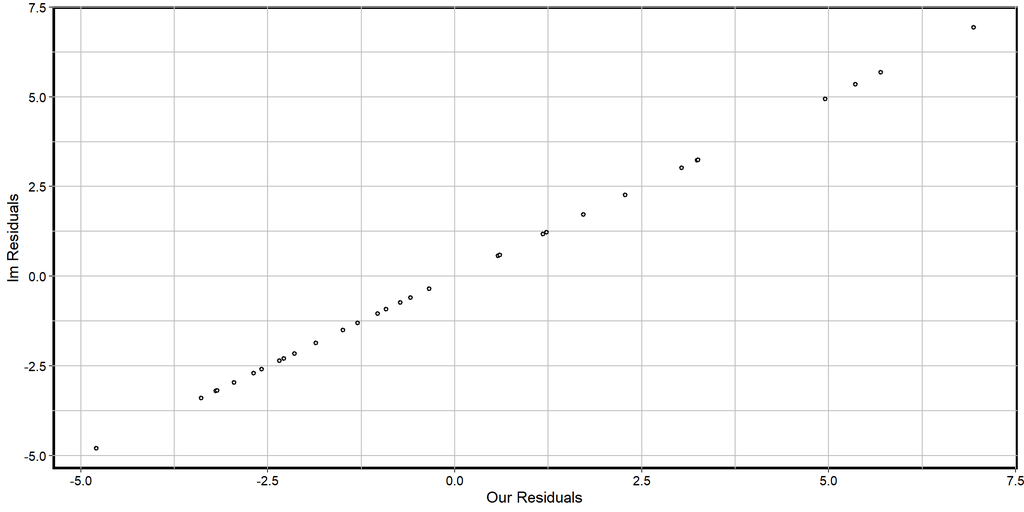

Our residuals vs lm residuals

```r
residuals_mt <- y_mt - predicted_mt

dt <- data.table(
  x = residuals_mt[,1],
  y = mpg_formula_obj$residuals
)

RplotterPkg::create_scatter_plot(
  df = dt,
  aes_x = "x",
  aes_y = "y",
  x_title = "Our Residuals",
  y_title = "lm Residuals",
  rot_y_tic_label = T
)
```

## An Estimate of Error

> We can use the residuals we’ve calculated to help us find the standard errors of our beta estimates.

$$var(\hat{B}) = \sigma^{2}(X^{T}X)^{-1}$$
The above formula gives us the variance/co-variance among the betas. The square root of the diagonals of this matrix gives us the standard error for the betas.

The estimate for $\sigma^{2}$ is the following:

$$\hat{\sigma}^{2} = \frac{1}{N - p}(r^{T}r)$$

where $r$ is our vector of residuals, $N$ number of observations, $p$ the number of columns in the design matrix (intercept included).

```r
var_est <- as.numeric((1/(nrow(x_mt) - ncol(x_mt)))*t(residuals_mt) %*% residuals_mt)
```

Estimate for the variance is 9.7756357.

Knowing the variance, we can plug it into our formula for the betas variance/co-variance matrix:

```r
var_covar_beta_mt <- var_est * solve(XtX_mt)
print(var_covar_beta_mt)
```

```
               x0            hp          disp
x0    1.773068357 -0.0081943285 -0.0011510577
hp   -0.008194329  0.0001791716 -0.0000783970
disp -0.001151058 -0.0000783970  0.0000548319
```

Taking the square root of the diagonals of the var/co-variance matrix will give us the standard errors for the betas.

```r
beta_se_v <- sqrt(diag(var_covar_beta_mt))
print(beta_se_v)
```

```
         x0          hp        disp
1.331566129 0.013385499 0.007404856
```

This result compares with our *lm* result:

```r
mpg_formula_summary <- summary(mpg_formula_obj)
print(mpg_formula_summary$coefficients[4:6])
```

```
[1] 1.331566129 0.013385499 0.007404856
```

## Finishing up

Calculate the t-values for the betas.

```r
tvals_mt <- betas_mt/beta_se_v
print(tvals_mt)
```

```
          [,1]
x0   23.082522
hp   -1.855746
disp -4.098159
```

Calculate the p-values for the betas.

```r
pval_fun <- function(tval, x){2 * pt(abs(tval), df = nrow(x)-ncol(x), lower.tail = F)}
pvals_lst <- purrr::map(tvals_mt[,1], pval_fun, x = x_mt)
pvals_mt <- matrix(unlist(pvals_lst), byrow = T)
print(pvals_mt)
```

```
             [,1]
[1,] 3.262507e-20
[2,] 7.367905e-02
[3,] 3.062678e-04
```

Calculate $R^{2}$.

```r
r_sq <- sum((predicted_mt - mean(y_mt))^2)/sum((y_mt - mean(y_mt))^2)
```

$R^{2}$ = 0.7482402

Calculate adjusted $R^{2}$.

```r
r_sq_adj <- 1 - (((1 - r_sq) * (nrow(x_mt) - 1))/(nrow(x_mt)-(ncol(x_mt)-1)-1))
```

$R^{2}_{adj}$ = 0.7308774

Put all the calculations together.

```r
df <- data.frame(
  var = c("x0", "hp", "disp"),
  b = betas_mt[,1],
  se = beta_se_v,
  t_value = tvals_mt[,1],
  p_value = pvals_mt[,1],
  r2 = c(r_sq, NA, NA),
  adj_r2 = c(r_sq_adj, NA, NA)
)

RplotterPkg::create_table(
  x = df,
  decimals_lst = list(cols = c(2,3,4,5,6,7), decimal = 4),
  container_width_px = 400
)
```

| var | b | se | t_value | p_value | r2 | adj_r2 |
| --- | --- | --- | --- | --- | --- | --- |
| x0 | 30.7359 | 1.3316 | 23.0825 | 0.0000 | 0.7482 | 0.7309 |
| hp | −0.0248 | 0.0134 | −1.8557 | 0.0737 | NA | NA |
| disp | −0.0303 | 0.0074 | −4.0982 | 0.0003 | NA | NA |